# Validasi Jaringan Termal Eksternal J-Tube: Langkah 5c–5f

Progress Update — J-Tube vs Chippendale (2017) & Høyer-Hansen (2022) · Risk-Constrained Probabilistic Thermal Rating, J-Tube Kabel Ekspor Offshore Wind

Joko Pawitro — NRP 6022251005

Program Magister, Rekayasa Elektrik Berkelanjutan — Departemen Teknik Elektro, ITS

2026-09-28

## Agenda

1. **Progress minggu ini** (21–27 September) — status Langkah 5 dan apa yang berubah
2. **Rencana minggu depan** (28 Sep – 4 Okt) — eksplorasi model termal dinamis (transien)

Rincian:

- Rekap singkat RC ladder kabel terkubur — TB 880 Case 8 & Case 2 (5a, dilaporkan minggu lalu)
- **RC ladder J-tube** — jaringan pengganti T4, divalidasi terhadap Chippendale (2017) & Høyer-Hansen (2022) (5c, baru)
- Progress tambahan — uji arah fisika (5d), konstanta waktu (5e), *forward solver* + precompute (5f)
- Rencana: RC ladder J-tube *submerged* & kabel *totally exposed*, dan arsitektur *solver* dinamis lintas 4 regime (HD7)

## 1. Progress — status Langkah 5 (model termal J-tube)

| # | Langkah | Status | Catatan |
| --- | --- | --- | --- |
| 1–3 | Data ERA5, tahun representatif, *wind-to-current* | ✅ Selesai | Dilaporkan minggu-minggu sebelumnya |
| 5a | Rugi-rugi + T1–T3 (TB 880 Case 8, Case 2) | ✅ Selesai | Dilaporkan **minggu lalu** — direkap singkat di slide 3–4 |
| 5b-i | TB 908 Method 1 *standalone* | ✅ Selesai | Dilaporkan minggu lalu; **5b-ii** (integrasi ke iterasi rating) masih ditunda, menunggu keputusan HD3 |
| **5c** | **Jaringan eksternal J-tube (ganti T4)** | 🟡 **Selesai dengan catatan** | **Baru minggu ini** — divalidasi terhadap Chippendale (2017); slide 5–6 |
| 5d | Uji arah fisika (*pytest*) | ✅ Selesai | **Baru minggu ini** — 88 tes (60 jalur *inverse* + 28 *forward*) |
| 5e | Konstanta waktu termal τ | ✅ Selesai | **Baru minggu ini** — rentang benchmark, kasus tesis ditunda ke HD3 |
| 5f | *Forward solver* `T_c(I)` + precompute Langkah 6 | ✅ Selesai | **Baru minggu ini** — `I_max(t)` per jam untuk 3 tahun representatif |
| 4 | Skenario *block-bootstrap* Monte Carlo | ❌ Belum | Diturunkan prioritasnya; tidak butuh Langkah 5 |
| 6–9 | `I_α`, umur XLPE, baseline + sensitivitas, pelaporan | ❌ Belum | Langkah 5 **selesai kecuali 5b-ii** — tetapi Langkah 6 belum otomatis terbuka (lihat slide 9) |

**Langkah 5 kini selesai kecuali 5b-ii.** Total suite tes: **409 terpenuhi** (317 di awal pekan → 409 sekarang).

## 1. Progress — apa yang berubah minggu ini

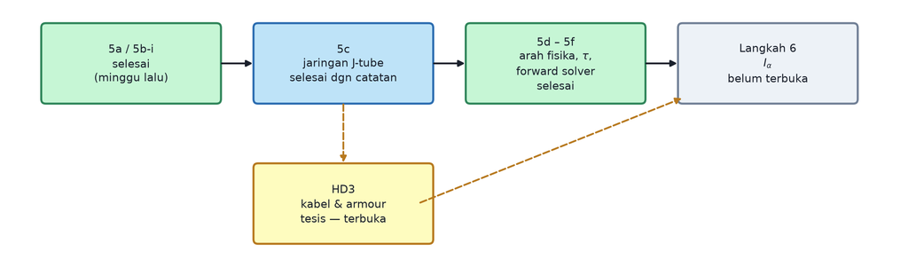

**Berbeda dari yang dijadwalkan:**

- **5c bukan “cocok dengan 828 A”** — hasil 812.8 A duduk di dalam rentang 2D-vs-FE Chippendale sendiri (−4,7 %), bukan mereproduksi FE. Ditemukan dua penyebab gap awal (~7 %): (1) GP 25 (TB 880) salah diterapkan pada benchmark era IEC 2006 — diperbaiki; (2) korelasi permukaan luar diganti dari Churchill–Chu ke Hartlein & Black (1983), sumber yang benar-benar dikutip Chippendale.
- **Langkah 5 selesai secara sub-langkah, tetapi Langkah 6 belum otomatis terbuka**: masih menunggu skenario Langkah 4, keputusan pemetaan angin→koefisien permukaan luar (`h_ext`), dan HD3 (kabel & armour kasus tesis).

## 2. Rekap — RC ladder kabel terkubur (5a)

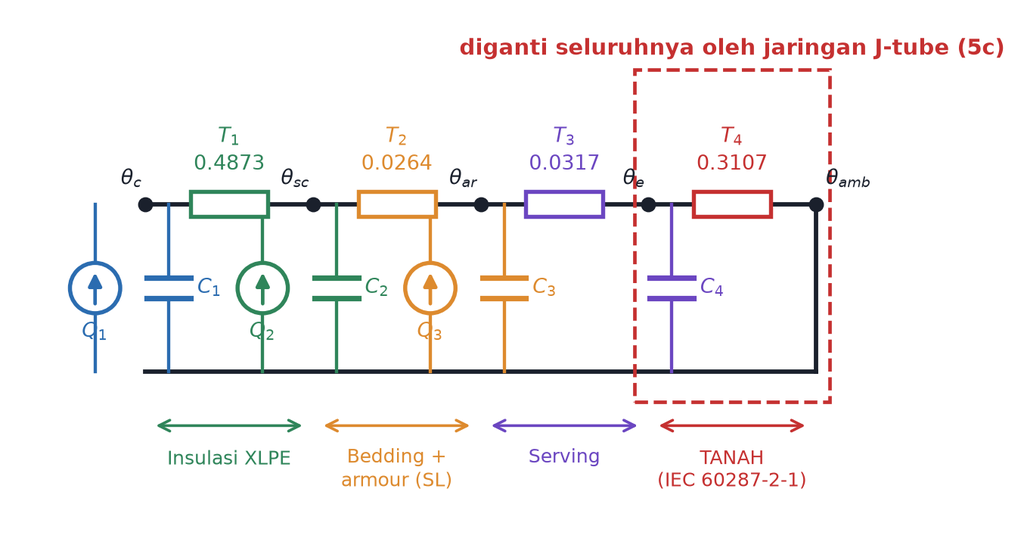

Nilai resistansi (K·m/W) di atas adalah hasil hitung TB 880 Case 8 dari `src/`. **Sumber panas:** `Q₁` = rugi konduktor + ½ rugi dielektrik; `Q₂` = rugi sheath (+ ½ `W_d`); `Q₃` = rugi armour. **Kapasitansi `C₁`–`C₄` ditampilkan sebagai simbol saja** — model rating inti bersifat **kuasi-stasioner**, jadi hanya `R` yang dipakai; `C` baru dihitung pada 5e (konstanta waktu) dan menjadi dasar kerja transien minggu depan.

`T₁`–`T₃` adalah agregat per-lapisan (`t1_layered` menjumlah lapisan *conductor screen*, insulasi, *insulation screen*, *water-blocking tape*). Case 2 memakai topologi yang sama dengan jalur armour magnetik aktif (`λ₂ ≠ 0`) dan iterasi dua-temperatur (`θ_sc`, `θ_ar`).

## 2. Rekap — hasil validasi RC ladder kabel terkubur

|  | Case 8 — non-magnetik | Case 2 — magnetik |
| --- | --- | --- |
| Kabel | FXBLTV 3x1000 mm2, 220 kV | 3x630 mm2 CU/XLPE/PB/SCPE/PPY/SWA/PPY 18/30 (36) kV, 30 kV |
| Armour | baja tahan karat — λ₂ = 0 | baja galvanis — λ₂ dari IEC 5.4.3.3.1 |
| I akhir (A) | 1134.82 | 838.34 |
| GP 2 (A) | 1130 | 830 |
| Kontribusi `T₄` (tanah) terhadap ΔΘ | **65 %** | **68 %** |

Setiap nilai antara published (rugi-rugi, `T₁`–`T₃`, arus akhir) cocok pada `rel ≤ 1e-9` terhadap TB 880 — 226 tes, dilaporkan minggu lalu. Kedua kasus memvalidasi **lapisan internal kabel** (IEC 60287-1-1/-2-1), **bukan** model J-tube.

Baris terakhir adalah intinya: porsi kenaikan suhu yang ditanggung `T₄` tanah adalah **porsi yang harus digantikan seluruhnya** ketika kabel berpindah dari dasar laut ke dalam J-tube — akan ditampilkan pada slide selanjutnya terkait progress 5c minggu ini.

**Rujukan:** CIGRE TB 880 (2022), Case Study 8 & 2; IEC 60287-1-1:2023; IEC 60287-2-1:2023.

## 3. RC ladder J-tube — jaringan pengganti T4 (5c)

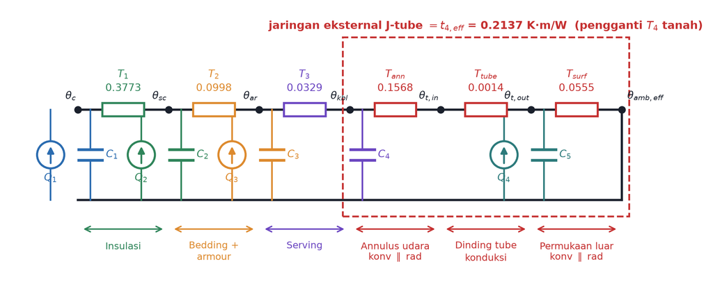

Tiga elemen di dalam kotak merah menggantikan `T₄` tanah. Keduanya **tak-linear** (annulus bergantung Rayleigh; radiasi ∝ T⁴), sehingga jaringan diselesaikan untuk suatu aliran panas `W` lalu **direduksi** menjadi satu `t₄,eff` plus ambien efektif yang membawa offset surya — agar tetap masuk ke slot `T₄` pada `rating_with_sheath_iteration` yang **tidak diubah**. Jalur `T₁`–`T₃` dan SL/armour dari 5a dipakai apa adanya.

`Q₄` = fluks surya terserap di permukaan luar tube (bukan resistansi, tetapi sumber panas di simpul itu). `C₅` = kapasitansi dinding tube baja; annulus udara praktis tidak menyimpan panas (`C ≈ 0`, dikonfirmasi 5e).

## 3. RC ladder J-tube — persamaan dan parameter benchmark

$$\begin{aligned}
Nu_\text{annulus} &= 0.188\,Ra^{0.322}\left(\tfrac{L}{\delta_g}\right)^{-0.238}\left(\tfrac{D_i}{D_\text{kabel}}\right)^{0.442} &&\text{(Keyhani et al. 1985)}\\
Nu_\text{luar} &= c\,(Gr\,Pr)^n,\quad (c,n) \in \{(0.59,\,0.25),\ (0.021,\,0.40)\} &&\text{(Hartlein & Black 1983, Tabel I)}\\
t_{4,\text{eff}} &= T_\text{ann} + T_\text{tube} + T_\text{surf}, \qquad \theta_{\text{amb,eff}} = \theta_\text{amb} + Q_\text{solar}\cdot T_\text{surf}
\end{aligned}$$

| Item | Chippendale et al. (2017) |
| --- | --- |
| Kabel | 1000 mm² 132 kV 3-phase XLPE/lead/steel SL type |
| J-tube (r dalam / luar) | 237.5 / 277.5 mm, baja k = 18 W/m·K |
| Panjang seksi udara | 15 m |
| Ambien / surya | 30 °C, 500 W/m² (α = 0.4, ε = 0.9) |
| Target FE / 2D analitis | 828 A / 789 A (-4.7 % vs FE) |

Konstruksi armour (jumlah kawat, diameter, *lay*) **tidak dipublikasikan** Chippendale — diperlakukan sebagai asumsi rekonstruksi benchmark saja, bukan keputusan kasus tesis (HD3). Annulus dimodelkan sebagai kolom udara **tersegel** (HD6) — konsisten dengan korelasi Keyhani yang memang untuk annulus tertutup, dan merupakan sisi konservatif.

## 3. RC ladder J-tube — hasil validasi

| Metrik | Nilai |
| --- | --- |
| Rating (asumsi armour 0,85 / 12,5) | **812.8 A** |
| vs 2D analitis Chippendale (789 A) | +3.0 % |
| vs FE Chippendale (828 A) | -1.8 % |
| Rentang band armour (9 asumsi) | 812.7 – 814.1 A |
| `t₄,eff` (pengganti `T₄` tanah) | 0.2137 K·m/W |
| θ permukaan kabel | 72.5 °C |

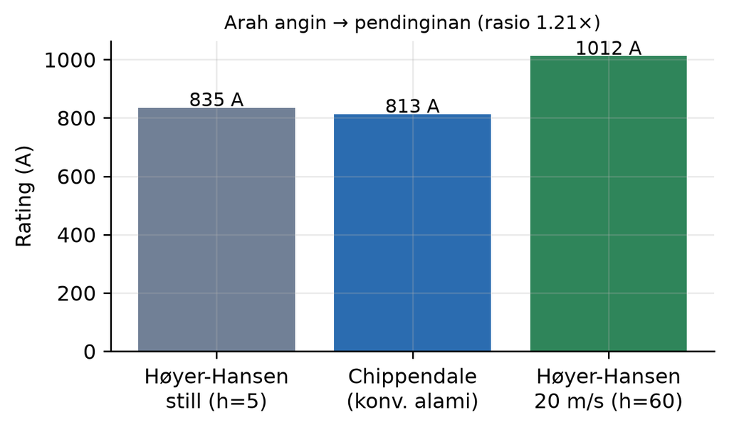

**Hasil 812.8 A duduk di dalam rentang 2D-vs-FE Chippendale sendiri (−4,7 %)** — konsisten dengan metode 2D-nya, **bukan** “tervalidasi terhadap FE”. Cross-check Høyer-Hansen (2022) hanya menegaskan arah fisika (angin ↑ → rating ↑), bukan pencocokan numerik.

**Dibawa ke Langkah 8 sebagai sensitivitas:** konvensi luas perpindahan-panas annulus (dominan, +3,7 % satu-sisi), korelasi permukaan luar (sudah bersumber, 2,8 %), kondisi ventilasi annulus (HD6), dan koreksi 3D longitudinal (≈ +2,5 %, di luar cakupan — konservatif).

**Rujukan:** Chippendale, Pilgrim, Goddard, Cangy (2017), *IEEE Trans. Power Delivery* 32(3), 1721–1729; Høyer-Hansen et al. (2022), *J. Phys.: Conf. Ser.* 2362, 012019; Hartlein & Black (1983), *IEEE Trans. Power App. Syst.* PAS-102(6), 1678–1686; Keyhani, Kulacki, Christensen (1985), *J. Heat Transfer* 107, 611–623.

## 4. Progress tambahan — 5d, 5e, 5f

[output not shown]

**Total suite tes: 409 terpenuhi, `ruff` bersih.** Yang masih mengunci Langkah 6: skenario Langkah 4 (belum dibangun), pemetaan angin→`h_ext` (belum diputuskan), dan HD3 (kabel & armour kasus tesis).

## 5. Rencana minggu depan — RC ladder *submerged* & *totally exposed*

Minggu depan, eksplorasi model **dinamis (transien)** lintas empat regime batas mulai dikerjakan (HD7 — cakupan masih terbuka: amandemen lingkup inti vs. eksplorasi khusus).

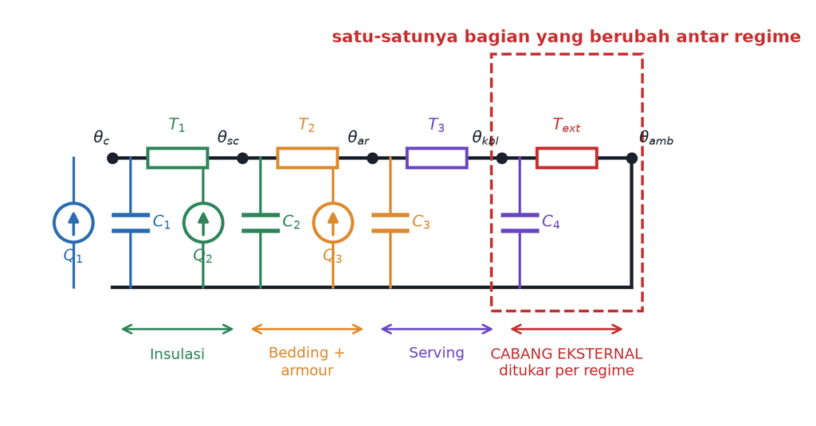

**Satu RC ladder internal bersama** (`T₁`–`T₃` + `C₁`–`C₄`, identik dengan model kuasi-stasioner inti) memberikan masukan ke cabang eksternal yang ditukar. Kapasitansi yang selama ini hanya simbol menjadi **aktif** pada model transien.

## 5. Rencana minggu depan — empat regime dan batasnya

| Regime | Karakter batas | Cabang eksternal `T_ext` |
| --- | --- | --- |
| J-tube (udara) — kasus inti | Padat + annulus udara tersegel, kapasitansi nyata | Jaringan 5c (annulus ∥ rad → dinding → permukaan), ditambah node kapasitif |
| **J-tube *submerged*** — tube di air laut, kabel tetap di dalam | Permukaan luar tube melihat konveksi air laut (h tinggi), bukan udara ambien | Jaringan internal J-tube **sama**; hanya korelasi batas luar diganti dari udara (Hartlein–Black) ke koefisien film air laut |
| **Kabel *totally exposed*** — langsung di air laut, tanpa tube | h eksternal sangat tinggi | Sisi luar ≈ isotermal pada suhu laut; respons transien didominasi kapasitansi internal kabel (`C₁`–`C₄`) |
| Terkubur | Tanah semi-tak-hingga, difusi, tanpa kapasitansi terbatas | **Tidak bisa** jadi RC *lumped* seperti tiga di atas — perlu superposisi faktor pencapaian IEC 60853-2 |

**Modal yang bisa dipakai ulang:** `chippendale_layer_capacitances()` (kapasitansi per-lapisan, sudah ada dari 5e) dan rentang τ benchmark (4–11 jam) sebagai orde-besar awal untuk J-tube udara dan J-tube *submerged*.

**Yang perlu dikerjakan minggu depan:** membangun satu *solver* transien untuk keluarga J-tube (udara + *submerged*), memakai ulang kapasitansi per-lapisan yang sudah ada dari 5e; kasus terkubur dikaji dulu sebagai metode literatur bila waktu terbatas, bukan kode baru. Substitusi geometri kasus tesis (HD3) dan penyambungan ke Langkah 4/6/7 (`I_α`, EAH) tetap di luar cakupan minggu ini.

**Rujukan yang dibutuhkan:** IEC 60853-2 (faktor pencapaian untuk kasus terkubur) dan parameter koefisien film konveksi air laut untuk J-tube *submerged* (sumbernya belum diidentifikasi).

## 6. Ringkasan

- **Langkah 5 (model termal J-tube) selesai kecuali 5b-ii.** Milestone utama minggu ini: RC ladder J-tube (5c) — jalur kritis jadwal — sudah dibangun dan divalidasi terhadap Chippendale (2017); hasil 812.8 A duduk di dalam rentang 2D-vs-FE metode Chippendale sendiri.
- **Bukan klaim “cocok dengan FE 828 A”** — dua penyebab gap awal (basis GP 25, korelasi permukaan luar) ditelusuri ke sumbernya, bukan disetel agar cocok.
- **88 tes arah fisika (5d)** menjaga model dari regresi diam-diam saat Langkah 6 dibangun; **konstanta waktu (5e)** menunjukkan sistem lebih lambat dari perkiraan awal tanpa mengubah justifikasi kuasi-stasioner; **forward solver + precompute (5f)** menyiapkan `I_max(t)` untuk Langkah 6.
- **Langkah 6 belum otomatis terbuka**: menunggu skenario Langkah 4, keputusan pemetaan angin→pendinginan, dan HD3 (kabel & armour kasus tesis).
- **Minggu depan:** eksplorasi *solver* transien lintas 4 regime — J-tube udara, J-tube *submerged*, kabel *totally exposed*, dan terkubur — di atas satu RC ladder internal bersama.

## 6. Dokumen rujukan

| Dokumen | Dipakai untuk | Status |
| --- | --- | --- |
| Chippendale, Pilgrim, Goddard, Cangy (2017), *IEEE Trans. Power Delivery* 32(3), 1721–1729 | Benchmark utama J-tube (5c): geometri, kondisi batas, target FE/2D | Terverifikasi; hasil dalam rentang 2D-vs-FE metode sendiri |
| Høyer-Hansen et al. (2022), *J. Phys.: Conf. Ser.* 2362, 012019 | *Cross-check* arah angin→pendinginan (5c) | Terverifikasi; pemeriksaan arah, bukan target numerik |
| Hartlein & Black (1983), *IEEE Trans. Power App. Syst.* PAS-102(6), 1678–1686 | Korelasi konveksi alami permukaan luar tube (5c) | Terverifikasi (dikutip langsung oleh Chippendale Eq. 12) |
| Keyhani, Kulacki, Christensen (1985), *J. Heat Transfer* 107, 611–623 | Korelasi Nusselt konveksi annulus (5c) | Terverifikasi (dikutip langsung oleh Chippendale Eq. 19) |
| CIGRE TB 880 (2022), *Current Rating Verification* | Case Study 8 & 2 (5a, direkap) | Terverifikasi minggu lalu; **bukan** benchmark J-tube |
| IEC 60287-1-1:2023, IEC 60287-2-1:2023 | Rantai rugi-rugi & `T₁`–`T₃` internal (dipakai apa adanya oleh 5c) | Terverifikasi |
| You et al. (2018), *Energies* 11(3), 545 | Kandidat sensitivitas Langkah 8 — J-tube berventilasi (pembanding HD6) | Dikutip; parameter belum diekstrak |
| IEC 60853-2 | Metode faktor-pencapaian untuk regime terkubur (rencana minggu depan) | Dikutip untuk rencana; belum diimplementasikan |